# AIRLINE PASSENGERS SATISFACTION: CLASSIFICATION

16/06/2023

## Database description

The following database contains information about airline customers, the flight they took and the results of a satisfaction questionnaire about their flight experience. The goal of our analysis is trying to predict whether customers were overall satisfied or not of their flight experience.

## Variable description

- …1: Index column
- Gender: Refers to the gender of the customer, either male or female.
- Customer Type: Indicates whether the customer is a loyal customer (someone who frequently chooses the same airline or company) or a disloyal customer (someone who doesn’t consistently choose the same airline or company).
- Age: Represents the age of the customer.
- Type of Travel: Specifies the purpose of the customer’s travel, such as personal travel or business travel.
- Customer Class: Indicates the class or category in which the customer traveled, such as Economy Plus or Business.
- Flight Distance: Represents the distance traveled by the customer’s flight.
- Inflight Wi-Fi Service: Rates the satisfaction level of the customer with the inflight Wi-Fi service on a scale of 0 to 5.
- Departure/Arrival Time Convenience: Rates the satisfaction level of the customer with the convenience of departure and arrival times on a scale of 0 to 5.
- Ease of Online Booking: Rates the satisfaction level of the customer with the ease of booking flights online on a scale of 0 to 5.
- Gate Location: Rates the satisfaction level of the customer with the gate location at the airport on a scale of 0 to 5.
- Food and Drink: Rates the satisfaction level of the customer with the quality of food and drink provided on the flight on a scale of 0 to 5.
- Online Boarding: Rates the satisfaction level of the customer with the online boarding process on a scale of 0 to 5.
- Seat Comfort: Rates the satisfaction level of the customer with the comfort of the seats on the flight on a scale of 0 to 5.
- Inflight Entertainment: Rates the satisfaction level of the customer with the inflight entertainment options on a scale of 0 to 5.
- Onboard Service: Rates the satisfaction level of the customer with the service provided by the flight crew on a scale of 0 to 5.
- Leg Room Service: Rates the satisfaction level of the customer with the legroom space on the flight on a scale of 0 to 5.
- Baggage Handling: Rates the satisfaction level of the customer with the handling of baggage by the airline on a scale of 1 to 5.
- Check-in Service: Rates the satisfaction level of the customer with the check-in service at the airport on a scale of 0 to 5.
- Inflight Service: Rates the satisfaction level of the customer with the overall inflight service on a scale of 0 to 5.
- Cleanliness: Rates the satisfaction level of the customer with the cleanliness of the aircraft on a scale of 0 to 5.
- Departure Delay in Minutes: Specifies the number of minutes of departure delay experienced by the customer.
- Arrival Delay in Minutes: Specifies the number of minutes of arrival delay experienced by the customer.
- Satisfaction: Represents the overall satisfaction level of the customer with their travel experience, categorized as either “satisfied” or “neutral or dissatisfied”

# OUTLINE

1. **Data upload**
2. **Exploratory analysis:**
   - missing values handling
   - outliers analysis
   - variables density
   - customer satisfaction distribution for categorical variables
   - customer satisfaction distribution for continuous variables
   - correlation matrix
3. **Train and test sets split**
4. **Logistic regression:**
   - general logistic model
   - forward step-wise models analysis
   - cross-validation
   - models comparison based on R-squared, CV error, CP
   - models selection (maybe one model per criteria if they differs)
   - models evaluation (accuracy, specificity, sensitivity, …)
   - ROC curve
5. **Linear Discriminant Analysis:**
   - …
   - compare LDA and logistic
6. **Tree predictors:**
   - …
   - comparison with logistic model
7. **Conclusion and Interpretation**

## Libraries

```r
library(tidyverse)
```

```r
library(dplyr)
library(ggplot2)
library(grid)
library(corrr)
```

# 1) DATA

```r
df <- read_csv("dataset/airline_passenger_satisfaction.csv")
```

```
## ──────────────────────────────────────────────────────── Delimiter: "," chr
## (5): Gender, customer_type, type_of_travel, customer_class, satisfaction dbl
## (19): ...1, age, flight_distance, inflight_wifi_service, departure_arriv...
```

```r
head(df)
```

| ...1 | Gender | customer_type | age | type_of_travel | customer_class | flight_distance | inflight_wifi_service | departure_arrival_time_convenient | ease_of_online_booking | gate_location | food_and_drink | online_boarding | seat_comfort | inflight_entertainment | onboard_service | leg_room_service | baggage_handling | checkin_service | inflight_service | cleanliness | departure_delay_in_minutes | arrival_delay_in_minutes | satisfaction |
| --- | --- | --- | --- | --- | --- | --- | --- | --- | --- | --- | --- | --- | --- | --- | --- | --- | --- | --- | --- | --- | --- | --- | --- |
| 0 | Male | Loyal Customer | 13 | Personal Travel | Eco Plus | 460 | 3 | 4 | 3 | 1 | 5 | 3 | 5 | 5 | 4 | 3 | 4 | 4 | 5 | 5 | 25 | 18 | neutral or dissatisfied |
| 1 | Male | disloyal Customer | 25 | Business travel | Business | 235 | 3 | 2 | 3 | 3 | 1 | 3 | 1 | 1 | 1 | 5 | 3 | 1 | 4 | 1 | 1 | 6 | neutral or dissatisfied |
| 2 | Female | Loyal Customer | 26 | Business travel | Business | 1142 | 2 | 2 | 2 | 2 | 5 | 5 | 5 | 5 | 4 | 3 | 4 | 4 | 4 | 5 | 0 | 0 | satisfied |
| 3 | Female | Loyal Customer | 25 | Business travel | Business | 562 | 2 | 5 | 5 | 5 | 2 | 2 | 2 | 2 | 2 | 5 | 3 | 1 | 4 | 2 | 11 | 9 | neutral or dissatisfied |
| 4 | Male | Loyal Customer | 61 | Business travel | Business | 214 | 3 | 3 | 3 | 3 | 4 | 5 | 5 | 3 | 3 | 4 | 4 | 3 | 3 | 3 | 0 | 0 | satisfied |
| 5 | Female | Loyal Customer | 26 | Personal Travel | Eco | 1180 | 3 | 4 | 2 | 1 | 1 | 2 | 1 | 1 | 3 | 4 | 4 | 4 | 4 | 1 | 0 | 0 | neutral or dissatisfied |

### Dataset structure

```r
str(df)
```

```
## spc_tbl_ [129,880 × 24] (S3: spec_tbl_df/tbl_df/tbl/data.frame)
##  $ ...1                             : num [1:129880] 0 1 2 3 4 5 6 7 8 9 ...
##  $ Gender                           : chr [1:129880] "Male" "Male" "Female" "Female" ...
##  $ customer_type                    : chr [1:129880] "Loyal Customer" "disloyal Customer" "Loyal Customer" "Loyal Customer" ...
##  $ age                              : num [1:129880] 13 25 26 25 61 26 47 52 41 20 ...
##  $ type_of_travel                   : chr [1:129880] "Personal Travel" "Business travel" "Business travel" "Business travel" ...
##  $ customer_class                   : chr [1:129880] "Eco Plus" "Business" "Business" "Business" ...
##  $ flight_distance                  : num [1:129880] 460 235 1142 562 214 ...
##  $ inflight_wifi_service            : num [1:129880] 3 3 2 2 3 3 2 4 1 3 ...
##  $ departure_arrival_time_convenient: num [1:129880] 4 2 2 5 3 4 4 3 2 3 ...
##  $ ease_of_online_booking           : num [1:129880] 3 3 2 5 3 2 2 4 2 3 ...
##  $ gate_location                    : num [1:129880] 1 3 2 5 3 1 3 4 2 4 ...
##  $ food_and_drink                   : num [1:129880] 5 1 5 2 4 1 2 5 4 2 ...
##  $ online_boarding                  : num [1:129880] 3 3 5 2 5 2 2 5 3 3 ...
##  $ seat_comfort                     : num [1:129880] 5 1 5 2 5 1 2 5 3 3 ...
##  $ inflight_entertainment           : num [1:129880] 5 1 5 2 3 1 2 5 1 2 ...
##  $ onboard_service                  : num [1:129880] 4 1 4 2 3 3 3 5 1 2 ...
##  $ leg_room_service                 : num [1:129880] 3 5 3 5 4 4 3 5 2 3 ...
##  $ baggage_handling                 : num [1:129880] 4 3 4 3 4 4 4 5 1 4 ...
##  $ checkin_service                  : num [1:129880] 4 1 4 1 3 4 3 4 4 4 ...
##  $ inflight_service                 : num [1:129880] 5 4 4 4 3 4 5 5 1 3 ...
##  $ cleanliness                      : num [1:129880] 5 1 5 2 3 1 2 4 2 2 ...
##  $ departure_delay_in_minutes       : num [1:129880] 25 1 0 11 0 0 9 4 0 0 ...
##  $ arrival_delay_in_minutes         : num [1:129880] 18 6 0 9 0 0 23 0 0 0 ...
##  $ satisfaction                     : chr [1:129880] "neutral or dissatisfied" "neutral or dissatisfied" "satisfied" "neutral or dissatisfied" ...
##  - attr(*, "spec")=
##   .. cols(
##   ..   ...1 = col_double(),
##   ..   Gender = col_character(),
##   ..   customer_type = col_character(),
##   ..   age = col_double(),
##   ..   type_of_travel = col_character(),
##   ..   customer_class = col_character(),
##   ..   flight_distance = col_double(),
##   ..   inflight_wifi_service = col_double(),
##   ..   departure_arrival_time_convenient = col_double(),
##   ..   ease_of_online_booking = col_double(),
##   ..   gate_location = col_double(),
##   ..   food_and_drink = col_double(),
##   ..   online_boarding = col_double(),
##   ..   seat_comfort = col_double(),
##   ..   inflight_entertainment = col_double(),
##   ..   onboard_service = col_double(),
##   ..   leg_room_service = col_double(),
##   ..   baggage_handling = col_double(),
##   ..   checkin_service = col_double(),
##   ..   inflight_service = col_double(),
##   ..   cleanliness = col_double(),
##   ..   departure_delay_in_minutes = col_double(),
##   ..   arrival_delay_in_minutes = col_double(),
##   ..   satisfaction = col_character()
##   .. )
##  - attr(*, "problems")=<externalptr>
```

```r
summary(df)
```

```
##       ...1           Gender          customer_type           age
##  Min.   :     0   Length:129880      Length:129880      Min.   : 7.00
##  1st Qu.: 32470   Class :character   Class :character   1st Qu.:27.00
##  Median : 64940   Mode  :character   Mode  :character   Median :40.00
##  Mean   : 64940                                         Mean   :39.43
##  3rd Qu.: 97409                                         3rd Qu.:51.00
##  Max.   :129879                                         Max.   :85.00
##
##  type_of_travel     customer_class     flight_distance inflight_wifi_service
##  Length:129880      Length:129880      Min.   :  31    Min.   :0.000
##  Class :character   Class :character   1st Qu.: 414    1st Qu.:2.000
##  Mode  :character   Mode  :character   Median : 844    Median :3.000
##                                        Mean   :1190    Mean   :2.729
##                                        3rd Qu.:1744    3rd Qu.:4.000
##                                        Max.   :4983    Max.   :5.000
##
##  departure_arrival_time_convenient ease_of_online_booking gate_location
##  Min.   :0.000                     Min.   :0.000          Min.   :0.000
##  1st Qu.:2.000                     1st Qu.:2.000          1st Qu.:2.000
##  Median :3.000                     Median :3.000          Median :3.000
##  Mean   :3.058                     Mean   :2.757          Mean   :2.977
##  3rd Qu.:4.000                     3rd Qu.:4.000          3rd Qu.:4.000
##  Max.   :5.000                     Max.   :5.000          Max.   :5.000
##
##  food_and_drink  online_boarding  seat_comfort   inflight_entertainment
##  Min.   :0.000   Min.   :0.000   Min.   :0.000   Min.   :0.000
##  1st Qu.:2.000   1st Qu.:2.000   1st Qu.:2.000   1st Qu.:2.000
##  Median :3.000   Median :3.000   Median :4.000   Median :4.000
##  Mean   :3.205   Mean   :3.253   Mean   :3.441   Mean   :3.358
##  3rd Qu.:4.000   3rd Qu.:4.000   3rd Qu.:5.000   3rd Qu.:4.000
##  Max.   :5.000   Max.   :5.000   Max.   :5.000   Max.   :5.000
##
##  onboard_service leg_room_service baggage_handling checkin_service
##  Min.   :0.000   Min.   :0.000    Min.   :1.000    Min.   :0.000
##  1st Qu.:2.000   1st Qu.:2.000    1st Qu.:3.000    1st Qu.:3.000
##  Median :4.000   Median :4.000    Median :4.000    Median :3.000
##  Mean   :3.383   Mean   :3.351    Mean   :3.632    Mean   :3.306
##  3rd Qu.:4.000   3rd Qu.:4.000    3rd Qu.:5.000    3rd Qu.:4.000
##  Max.   :5.000   Max.   :5.000    Max.   :5.000    Max.   :5.000
##
##  inflight_service  cleanliness    departure_delay_in_minutes
##  Min.   :0.000    Min.   :0.000   Min.   :   0.00
##  1st Qu.:3.000    1st Qu.:2.000   1st Qu.:   0.00
##  Median :4.000    Median :3.000   Median :   0.00
##  Mean   :3.642    Mean   :3.286   Mean   :  14.71
##  3rd Qu.:5.000    3rd Qu.:4.000   3rd Qu.:  12.00
##  Max.   :5.000    Max.   :5.000   Max.   :1592.00
##
##  arrival_delay_in_minutes satisfaction
##  Min.   :   0.00          Length:129880
##  1st Qu.:   0.00          Class :character
##  Median :   0.00          Mode  :character
##  Mean   :  15.09
##  3rd Qu.:  13.00
##  Max.   :1584.00
##  NA's   :393
```

```r
# All the customer-generated variables are on a scales from 0 to 5 except for baggage handling that is on a scale from 1 to 5.
```

# 2) EXPLANATORY ANALYSIS

## Handling missing values

```r
# Function that counts NA values for each column
na_counts <- sapply(df, function(x) sum(is.na(x)))


# Calculate the percentage of NA values for each column
na_percentage <- na_counts / nrow(df) * 100

# Display a table with NA counts and percentages
na_table <- data.frame(Column = names(na_counts), NA_Count = na_counts, Percentage = na_percentage, row.names = NULL)

# na_table <- na_table[-1,]
na_table
```

| Column | NA_Count | Percentage |
| --- | --- | --- |
| ...1 | 0 | 0.000000 |
| Gender | 0 | 0.000000 |
| customer_type | 0 | 0.000000 |
| age | 0 | 0.000000 |
| type_of_travel | 0 | 0.000000 |
| customer_class | 0 | 0.000000 |
| flight_distance | 0 | 0.000000 |
| inflight_wifi_service | 0 | 0.000000 |
| departure_arrival_time_convenient | 0 | 0.000000 |
| ease_of_online_booking | 0 | 0.000000 |

[output cut: 14 more lines]

```r
# Count NA values in departure delay when the arrival delay is zero
zero_count <- sum(df$departure_delay_in_minutes == 0 & is.na(df$arrival_delay_in_minutes))

zero_count
```

```
## [1] 147
```

Missing values are present only for the column *arrival delay in minutes* for just a little bit more than 0.3% of the observations. We check if, as common sense might tell us, there is correlation between *departure delay in minutes.*

```r
correlation_dep_arr <- cor(df$departure_delay_in_minutes, df$arrival_delay_in_minutes, use = "complete.obs")

correlation_dep_arr
```

```
## [1] 0.9652912
```

The correlation is quite high, we then assume reasonable populationg the *arrival delay in minutes* NA using the variable *departure delay in minutes.*

```r
df$arrival_delay_in_minutes <- ifelse(is.na(df$arrival_delay_in_minutes), df$departure_delay_in_minutes, df$arrival_delay_in_minutes)


sum(is.na(df$arrival_delay_in_minutes))
```

```
## [1] 0
```

```r
# Alternative df where the NA are remove instead
df_na_deleted <- read_csv("dataset/airline_passenger_satisfaction.csv")
```

```
## ──────────────────────────────────────────────────────── Delimiter: "," chr
## (5): Gender, customer_type, type_of_travel, customer_class, satisfaction dbl
## (19): ...1, age, flight_distance, inflight_wifi_service, departure_arriv...
```

```r
df_na_deleted <- na.omit(df_na_deleted)
# df <- df_na_deleted
```

## Outliers analysis

The majority of variables take values on a fixed scale. The variables worth checking for outliers are: *departure delay in minutes*, *arrival delay in minutes*, *flight distance*.

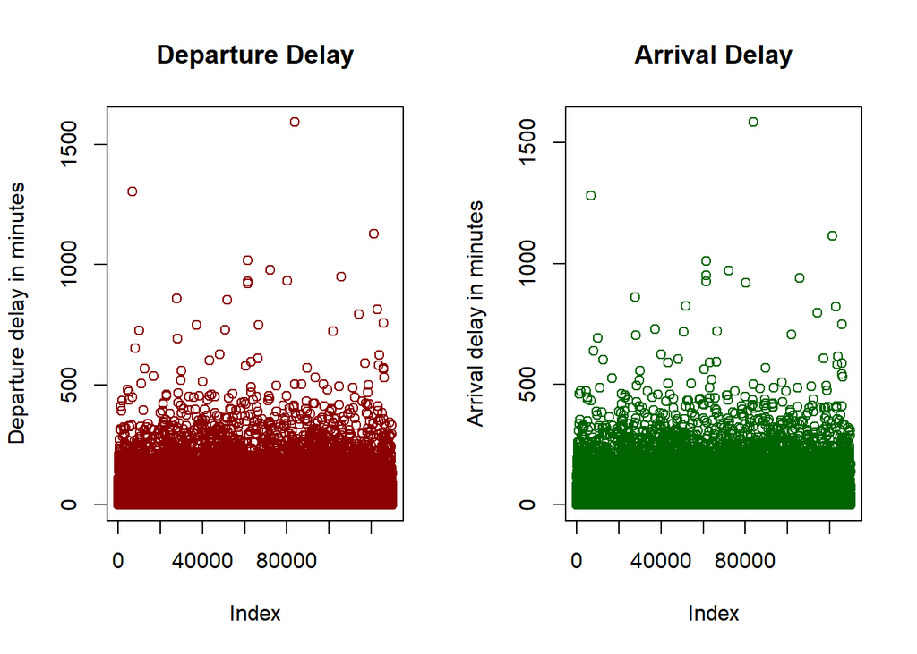

```r
par(mfrow = c(1, 2))

plot(df$departure_delay_in_minutes, main = "Departure Delay",
     xlab = "Index", ylab = "Departure delay in minutes", col = "darkred")

plot(df$arrival_delay_in_minutes, main = "Arrival Delay",
     xlab = "Index", ylab = "Arrival delay in minutes", col = "darkgreen")
```

[…]

```r
Q1 <- quantile(df$departure_delay_in_minutes, 0.25)
Q3 <- quantile(df$departure_delay_in_minutes, 0.75)
IQR <- Q3 - Q1

lower_threshold <- Q1 - 1.5 * IQR
upper_threshold <- Q3 + 1.5 * IQR

iqr_outliers <- df$departure_delay_in_minutes[df$departure_delay_in_minutes < Q1 - 1.5 * IQR |
                                              df$departure_delay_in_minutes > Q3 + 1.5 * IQR]
iqr_outlier_count <- length(iqr_outliers)

c("Outliers identified with the IQR method:", iqr_outlier_count)
```

```
## [1] "Outliers identified with the IQR method:"
## [2] "18098"
```

```r
c("Percentage of outliers identified:", iqr_outlier_count / length(df$departure_delay_in_minutes) * 100)
```

```
## [1] "Percentage of outliers identified:" "13.9344009855251"
```

```r
Q1 <- quantile(df$arrival_delay_in_minutes, 0.25)
Q3 <- quantile(df$arrival_delay_in_minutes, 0.75)
IQR <- Q3 - Q1

lower_threshold <- Q1 - 1.5 * IQR
upper_threshold <- Q3 + 1.5 * IQR

iqr_outliers <- df$arrival_delay_in_minutes[df$arrival_delay_in_minutes < Q1 - 1.5 * IQR |
                                              df$arrival_delay_in_minutes > Q3 + 1.5 * IQR]
iqr_outlier_count <- length(iqr_outliers)

c("Outliers identified with the IQR method:", iqr_outlier_count)
```

```
## [1] "Outliers identified with the IQR method:"
## [2] "17615"
```

```r
c("Percentage of outliers identified:", iqr_outlier_count / length(df$departure_delay_in_minutes) * 100)
```

```
## [1] "Percentage of outliers identified:" "13.5625192485371"
```

The IQR method does not look suitable to identify outliers because it identify almost 14% of observations as outliers. [For now I don’t really know which method to use for identify what outliers to remove]

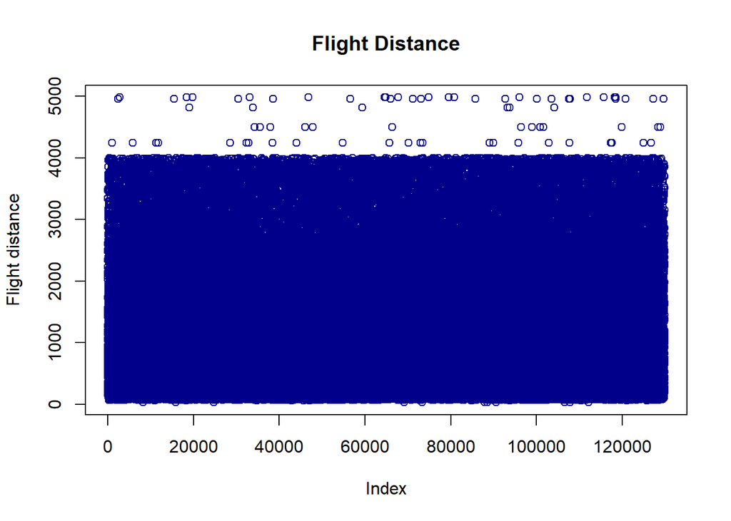

```r
plot(df$flight_distance, main = "Flight Distance",
     xlab = "Index", ylab = "Flight distance", col = "darkblue")
```

[…]

```r
# plot(df$age, main = "Customers' Age",
#     xlab = "Index", ylab = "Age")
# Is it worth plotting age too?
```

## Data cleaning

[I’m gonna remove the …1 column because it is just an extra index column]